# Hands-on Exercise 2

In this hands-on exercise, I will learn how to handle geospatial data in R by using sf package.

Niharika Avula https://example.com/norajones  
2021-09-01

```r
packages <- c('sf', 'tidyverse')
for (p in packages){
  if (!require(p, character.only = T)){
    install.packages(p)
  }
  library(p, character.only = T)
  }
```

# Importing Geospatial Data

## Importing polygon feature data in shapefile format

The code chunk below uses st_read() function of sf package to import MP14_SUBZONE_WEB_PL shapefile into R as a polygon feature data frame.

```r
mpsz = st_read(dsn =  "Data/Geospatial",
                  layer = "MP14_SUBZONE_WEB_PL")
```

## Importing polyline feature data in shapefile form

The code chunk below uses st_read() function of sf package to import CyclingPath shapefile into R as line feature data frame.

```r
cyclingpath = st_read(dsn = "data/geospatial",
                         layer = "CyclingPath")
```

## Importing GIS data in kml format

The code chunk below will be used to import the kml into R. Notice that in the code chunk below, the complete path and the kml file extension were provided

```r
preschool = st_read("data/geospatial/pre-schools-location-kml.kml")
```

# Checking the Content of a Simple Feature Data Frame

## Working with st_geometry()

```r
st_geometry(mpsz)
```

```
Geometry set for 323 features
Geometry type: MULTIPOLYGON
Dimension:     XY
Bounding box:  xmin: 2667.538 ymin: 15748.72 xmax: 56396.44 ymax: 50256.33
Projected CRS: SVY21
First 5 geometries:
```

## Working with glimpse()

glimpse() report reveals the data type of each fields.

```r
glimpse(mpsz)
```

```
Rows: 323
Columns: 16
$ OBJECTID   <int> 1, 2, 3, 4, 5, 6, 7, 8, 9, 10, 11, 12, 13, 14, 15~
$ SUBZONE_NO <int> 1, 1, 3, 8, 3, 7, 9, 2, 13, 7, 12, 6, 1, 5, 1, 1,~
$ SUBZONE_N  <chr> "MARINA SOUTH", "PEARL'S HILL", "BOAT QUAY", "HEN~
$ SUBZONE_C  <chr> "MSSZ01", "OTSZ01", "SRSZ03", "BMSZ08", "BMSZ03",~
$ CA_IND     <chr> "Y", "Y", "Y", "N", "N", "N", "N", "Y", "N", "N",~
$ PLN_AREA_N <chr> "MARINA SOUTH", "OUTRAM", "SINGAPORE RIVER", "BUK~
$ PLN_AREA_C <chr> "MS", "OT", "SR", "BM", "BM", "BM", "BM", "SR", "~
$ REGION_N   <chr> "CENTRAL REGION", "CENTRAL REGION", "CENTRAL REGI~
$ REGION_C   <chr> "CR", "CR", "CR", "CR", "CR", "CR", "CR", "CR", "~
$ INC_CRC    <chr> "5ED7EB253F99252E", "8C7149B9EB32EEFC", "C35FEFF0~
$ FMEL_UPD_D <date> 2014-12-05, 2014-12-05, 2014-12-05, 2014-12-05, ~
$ X_ADDR     <dbl> 31595.84, 28679.06, 29654.96, 26782.83, 26201.96,~
$ Y_ADDR     <dbl> 29220.19, 29782.05, 29974.66, 29933.77, 30005.70,~
$ SHAPE_Leng <dbl> 5267.381, 3506.107, 1740.926, 3313.625, 2825.594,~
$ SHAPE_Area <dbl> 1630379.3, 559816.2, 160807.5, 595428.9, 387429.4~
$ geometry   <MULTIPOLYGON [m]> MULTIPOLYGON (((31495.56 30..., MULT~
```

## Working with head()

```r
head(mpsz, n=5)
```

```
Simple feature collection with 5 features and 15 fields
Geometry type: MULTIPOLYGON
Dimension:     XY
Bounding box:  xmin: 25867.68 ymin: 28369.47 xmax: 32362.39 ymax: 30435.54
Projected CRS: SVY21
  OBJECTID SUBZONE_NO      SUBZONE_N SUBZONE_C CA_IND      PLN_AREA_N
1        1          1   MARINA SOUTH    MSSZ01      Y    MARINA SOUTH
2        2          1   PEARL'S HILL    OTSZ01      Y          OUTRAM
3        3          3      BOAT QUAY    SRSZ03      Y SINGAPORE RIVER
4        4          8 HENDERSON HILL    BMSZ08      N     BUKIT MERAH
5        5          3        REDHILL    BMSZ03      N     BUKIT MERAH
  PLN_AREA_C       REGION_N REGION_C          INC_CRC FMEL_UPD_D
1         MS CENTRAL REGION       CR 5ED7EB253F99252E 2014-12-05
2         OT CENTRAL REGION       CR 8C7149B9EB32EEFC 2014-12-05
3         SR CENTRAL REGION       CR C35FEFF02B13E0E5 2014-12-05
4         BM CENTRAL REGION       CR 3775D82C5DDBEFBD 2014-12-05
5         BM CENTRAL REGION       CR 85D9ABEF0A40678F 2014-12-05
    X_ADDR   Y_ADDR SHAPE_Leng SHAPE_Area
1 31595.84 29220.19   5267.381  1630379.3
2 28679.06 29782.05   3506.107   559816.2
3 29654.96 29974.66   1740.926   160807.5
4 26782.83 29933.77   3313.625   595428.9
5 26201.96 30005.70   2825.594   387429.4
                        geometry
1 MULTIPOLYGON (((31495.56 30...
2 MULTIPOLYGON (((29092.28 30...
3 MULTIPOLYGON (((29932.33 29...
4 MULTIPOLYGON (((27131.28 30...
5 MULTIPOLYGON (((26451.03 30...
```

# Plotting the Geospatial Data

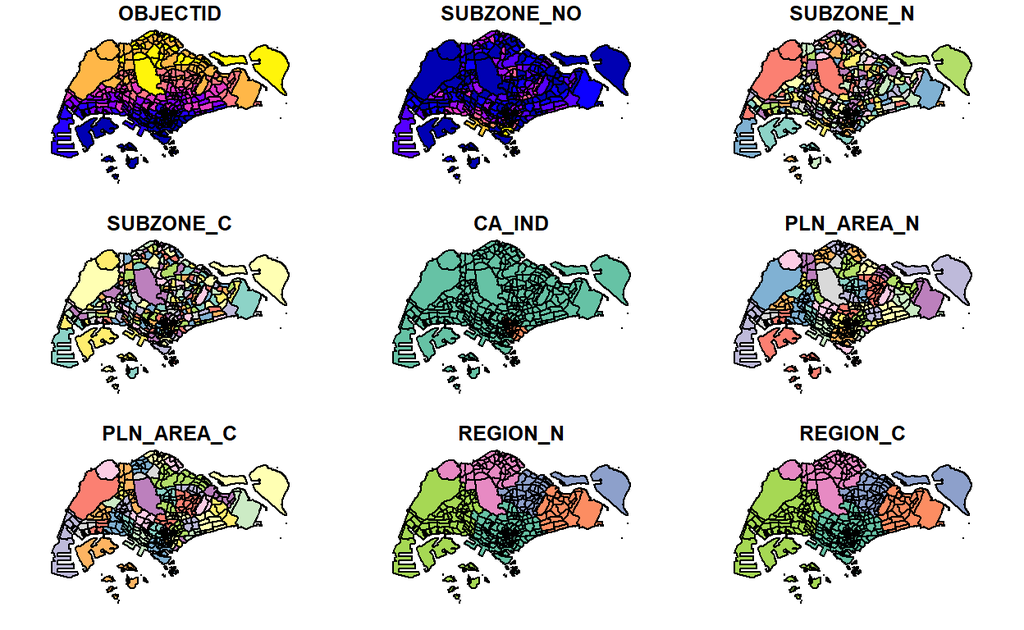

```r
plot(mpsz)
```

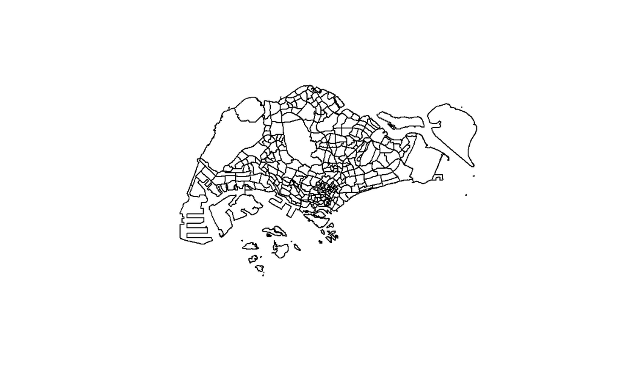

```r
plot(st_geometry(mpsz))
```

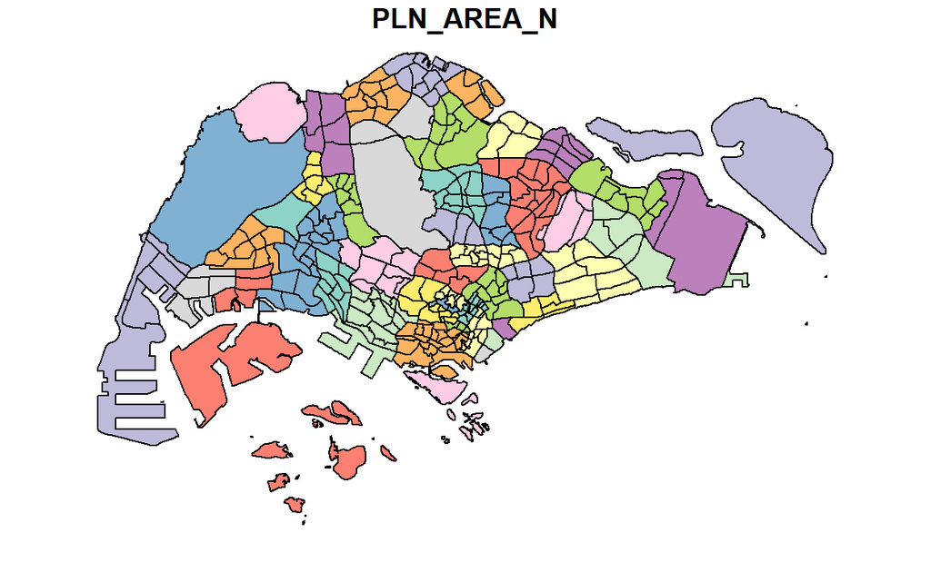

```r
plot(mpsz["PLN_AREA_N"])
```

# Working with Projection

```r
st_crs(mpsz)
```

```
Coordinate Reference System:
  User input: SVY21
  wkt:
PROJCRS["SVY21",
    BASEGEOGCRS["SVY21[WGS84]",
        DATUM["World Geodetic System 1984",
            ELLIPSOID["WGS 84",6378137,298.257223563,
                LENGTHUNIT["metre",1]],
            ID["EPSG",6326]],
        PRIMEM["Greenwich",0,
            ANGLEUNIT["Degree",0.0174532925199433]]],
    CONVERSION["unnamed",
        METHOD["Transverse Mercator",
            ID["EPSG",9807]],
        PARAMETER["Latitude of natural origin",1.36666666666667,
            ANGLEUNIT["Degree",0.0174532925199433],
            ID["EPSG",8801]],
        PARAMETER["Longitude of natural origin",103.833333333333,
            ANGLEUNIT["Degree",0.0174532925199433],
            ID["EPSG",8802]],
        PARAMETER["Scale factor at natural origin",1,
            SCALEUNIT["unity",1],
            ID["EPSG",8805]],
        PARAMETER["False easting",28001.642,
            LENGTHUNIT["metre",1],
            ID["EPSG",8806]],
        PARAMETER["False northing",38744.572,
            LENGTHUNIT["metre",1],
            ID["EPSG",8807]]],
    CS[Cartesian,2],
        AXIS["(E)",east,
            ORDER[1],
            LENGTHUNIT["metre",1,
                ID["EPSG",9001]]],
        AXIS["(N)",north,
            ORDER[2],
            LENGTHUNIT["metre",1,
                ID["EPSG",9001]]]]
```

## Assigning EPSG code to a simple feature data frame

```r
mpsz3414 <- st_set_crs(mpsz, 3414)
```

```r
st_crs(mpsz)
```

```
Coordinate Reference System:
  User input: SVY21
  wkt:
PROJCRS["SVY21",
    BASEGEOGCRS["SVY21[WGS84]",
        DATUM["World Geodetic System 1984",
            ELLIPSOID["WGS 84",6378137,298.257223563,
                LENGTHUNIT["metre",1]],
            ID["EPSG",6326]],
        PRIMEM["Greenwich",0,
            ANGLEUNIT["Degree",0.0174532925199433]]],
    CONVERSION["unnamed",
        METHOD["Transverse Mercator",
            ID["EPSG",9807]],
        PARAMETER["Latitude of natural origin",1.36666666666667,
            ANGLEUNIT["Degree",0.0174532925199433],
            ID["EPSG",8801]],
        PARAMETER["Longitude of natural origin",103.833333333333,
            ANGLEUNIT["Degree",0.0174532925199433],
            ID["EPSG",8802]],
        PARAMETER["Scale factor at natural origin",1,
            SCALEUNIT["unity",1],
            ID["EPSG",8805]],
        PARAMETER["False easting",28001.642,
            LENGTHUNIT["metre",1],
            ID["EPSG",8806]],
        PARAMETER["False northing",38744.572,
            LENGTHUNIT["metre",1],
            ID["EPSG",8807]]],
    CS[Cartesian,2],
        AXIS["(E)",east,
            ORDER[1],
            LENGTHUNIT["metre",1,
                ID["EPSG",9001]]],
        AXIS["(N)",north,
            ORDER[2],
            LENGTHUNIT["metre",1,
                ID["EPSG",9001]]]]
```

## Transforming the projection of preschool from wgs84 to svy21

```r
preschool3414 <- st_transform(preschool,
                              crs = 3414)
```

```r
preschool3414
```

```
Simple feature collection with 1925 features and 2 fields
Geometry type: POINT
Dimension:     XYZ
Bounding box:  xmin: 11203.01 ymin: 25596.33 xmax: 45404.24 ymax: 49300.88
z_range:       zmin: 0 zmax: 0
Projected CRS: SVY21 / Singapore TM
First 10 features:
     Name
1   kml_1
2   kml_2
3   kml_3
4   kml_4
5   kml_5
6   kml_6
7   kml_7
```

[output cut: 25 more lines]

# Importing and Converting An Aspatial Data

```r
listings <- read_csv("data/aspatial/listings.csv")
```

```r
glimpse(listings)
```

```
Rows: 4,252
Columns: 74
$ id                                           <dbl> 50646, 71609, 7~
$ listing_url                                  <chr> "https://www.ai~
$ scrape_id                                    <dbl> 2.021072e+13, 2~
$ last_scraped                                 <date> 2021-07-19, 20~
$ name                                         <chr> "Pleasant Room ~
$ description                                  <chr> "Fully furnishe~
$ neighborhood_overview                        <chr> "The serenity &~
$ picture_url                                  <chr> "https://a0.mus~
$ host_id                                      <dbl> 227796, 367042,~
$ host_url                                     <chr> "https://www.ai~
$ host_name                                    <chr> "Sujatha", "Bel~
$ host_since                                   <date> 2010-09-08, 20~
$ host_location                                <chr> "Singapore, Sin~
```

[output cut: 61 more lines]

## Creating a simple feature data frame from an aspatial data frame

```r
listings_sf <- st_as_sf(listings,
                       coords = c("longitude", "latitude"),
                       crs=4326) %>%
  st_transform(crs = 3414)
```

```r
glimpse(listings)
```

```
Rows: 4,252
Columns: 74
$ id                                           <dbl> 50646, 71609, 7~
$ listing_url                                  <chr> "https://www.ai~
$ scrape_id                                    <dbl> 2.021072e+13, 2~
$ last_scraped                                 <date> 2021-07-19, 20~
$ name                                         <chr> "Pleasant Room ~
$ description                                  <chr> "Fully furnishe~
$ neighborhood_overview                        <chr> "The serenity &~
$ picture_url                                  <chr> "https://a0.mus~
$ host_id                                      <dbl> 227796, 367042,~
$ host_url                                     <chr> "https://www.ai~
$ host_name                                    <chr> "Sujatha", "Bel~
$ host_since                                   <date> 2010-09-08, 20~
$ host_location                                <chr> "Singapore, Sin~
```

[output cut: 61 more lines]

# Geoprocessing with sf package

## Buffering

The scenario: The authority is planning to upgrade the exiting cycling path. To do so, they need to acquire 5 metres of reserved land on the both sides of the current cycling path. You are tasked to determine the extend of the land need to be acquired and their total area.

```r
buffer_cycling <- st_buffer(cyclingpath,
                               dist=5, nQuadSegs = 30)
```

```r
buffer_cycling$AREA <- st_area(buffer_cycling)
sum(buffer_cycling$AREA)
```

```
1642750 [m^2]
```